# Introduction to microarray data exploration and analysis with *basic* `R` functions

Alex Sanchez

# 1 Introduction

This document is intended as a short introduction to managing microarray data using `R` for people who are new to either microarrays, `R` or both.

The document is written followin open source reproducibility principles. The code to re-crete it is available from github at: https://github.com/ASPteaching/Analisis_de_datos_omicos-Ejemplo_0-Microarrays.

Although most people working with microarrays and `R` use the open source collection of packages compiled in `Bioconductor` no specific libraries will be used in this introduction. This is not the way you will proceed later in the course we start this way to emphasize that, in fact, omics data are *just* another type of data.

## 1.1 About the Gene Expression Omnibus (GEO) database

The data for this example is obtained from the GEO database. Although its use is relatively straightforward, one thing that can be confusing is the distinct types of identifiers that characterize a given study. In order to make it clear from the beginning we start with a quick review of what is stored in the GEO database.

The NCBI Gene Expression Omnibus (GEO) serves as a public repository for a wide range of high-throughput experimental data. These data include single and dual channel microarray-based experiments measuring mRNA, genomic DNA, and protein abundance, as well as non-array techniques such as serial analysis of gene expression (SAGE), mass spectrometry proteomic data, and high-throughput sequencing data.

At the most basic level of organization of GEO, there are four basic entity types. The first three (Sample, Platform, and Series) are supplied by users; the fourth, the dataset, is compiled and curated by GEO staff from the user-submitted data. More information is available in the [GEO site](https://www.ncbi.nlm.nih.gov/geo/info/overview.html) summarized by the image below:

[figure not shown]

GEO records organization

There are five distinct type of entities at GEO:

Three of these are submitted by the data supppliers

- **Plattforms**: Describe the the system used to generate the data. Each identifier corresponds to a commercial plattform such as Assymetrix, HGU133 plus 2 or Roche 454 sequencer. etc. Each platform has a unique accession number (GPLxxx).
- **Samples**: Information about each individual sample. Each platform has a unique accession number (GSMxxx).
- **Series**: A series links together a group of related samples and provides a focal point and description of the whole study. Each Series record is assigned a unique and stable GEO accession number (GSExxx).

The remaining two are elaborated by GEO.

- **Dataset** A DataSet represents a curated collection of biologically and statistically comparable GEO Samples *and forms the basis of GEO’s suite of data display and analysis tools*.
- **Profiles** A Profile consists of the expression measurements for an individual gene across all Samples in a DataSet.

Each type of entity has one identifier associated, so that the identifers for a given study are all related. The simplest way to obtain an overview of a study is to start by the Dataset Accession page: https://www.ncbi.nlm.nih.gov/sites/GDSbrowser?acc=GDS4155

[figure not shown]

It can be seen how this study has:

- Dataset accesion ID for : GDS4155
- Series accesion ID for : GSE27174
- Plattform accession ID : GPL6246

Although, indeed, it seems more reasonable to start from the DATASET page, it is very common that a give DataSet is associated with only one series. In those cases it is common practice to start from the Series page, which contains more information about the specific study. This is what is done in the example below.

# 2 A first look at microarray data. The study

This database allows uploading raw data but also pre-processed datasets in the form of “data matrix”. The data matrix for this study is available at the link shown below and it can be downloaded directly from there.

- [GSE27174_series_matrix.txt](https://ftp.ncbi.nlm.nih.gov/geo/series/GSE27nnn/GSE27174/matrix/)

The file is in linux compressed format “.gz” that need to be uncompressed before having access to the .txt file.

In the following we assume that you have downloaded the file and unzipped it in a sub-folder of your working directory named “data” pending from your working directory.

## 2.1 Downloading the data and loading it into R

The data matrix recovered from the web contains some general information first and the expression values for each sample after line 66.

The first thing to do is to separate both informations. This can be done using the `read.table()` command using the `skip` option:

```r
info <-readLines("data/GSE27174_series_matrix.txt", n=70)
x <-read.table("data/GSE27174_series_matrix.txt", skip=65, header=TRUE, sep="\t",row.names=1)
```

In order to understand the structure of the data we can proceed in two ways:

- Either inpect the header of the data matrix
- Or look for this information in the GEO web site.

```r
info[30]
```

```
## [1] "!Sample_title\t\"Fibroblasts dopaminergic induced rep1\"\t\"Fibroblasts dopaminergic induced rep2\"\t\"Fibroblasts dopaminergic induced rep3\"\t\"Fibroblasts dopaminergic induced rep4\"\t\"Fibroblasts not induced rep1\"\t\"Fibroblasts not induced rep2\"\t\"Fibroblasts not induced rep3\"\t\"F…
```

An inspection of the information available either in the matrix or in the web shows that there are two type of samples “Induced” and “not induced”. *We can re-label the columns of the data matrix* to work more fluently.

```r
colnames(x)
```

```
## [1] "GSM671653" "GSM671654" "GSM671655" "GSM671656" "GSM671657" "GSM671658"
## [7] "GSM671659" "GSM671660"
```

```r
colnames(x) <- paste(c(rep("DopaminInduc", 4), rep("NotInduced", 4)), c("01", "02", "03","04"), sep="")
colnames(x)
```

```
## [1] "DopaminInduc01" "DopaminInduc02" "DopaminInduc03" "DopaminInduc04"
## [5] "NotInduced01"   "NotInduced02"   "NotInduced03"   "NotInduced04"
```

## 2.2 Obtain the annotations

Each row in the array represents one *probeset* which, roughly, corresponds to one gene. In order to know to which gene each probeset is associated one needs to know what array type is using and to have the corresponding annotations table available.

An annotation table can be downloaded from this site and read into `R` to relate the probesets and their annotations. Again, this is a rudimentary way to proceed. In later exercises we will show a more efficient way to proceed using Bioconductor.

The file can be downloaded from the we page pressing the button “Download full table …” at the bottom of the page.

After downloading, we have the file `GPL6246-18741.txt` and can “look at it” by reading the first lines to have a feeling of how these annotations look like.

WARNING! This is a big file which may cause memory problems!

```r
infoAnots <-readLines("data/GPL6246-18741.txt", n=26)
annot <-read.delim2("data/GPL6246-18741.txt", comment.char="#")
dim(annot)
```

```
## [1] 35557    12
```

```r
head(annot[1:5, c(1:4,10)])
```

```
##         ID           GB_LIST              SPOT_ID seqname
## 1 10344614 AK145513,AK145782 chr1:3054233-3054733    chr1
## 2 10344616                   chr1:3102016-3102125    chr1
## 3 10344618                   chr1:3276323-3277348    chr1
## 4 10344620          AK140060 chr1:3680571-3680912    chr1
## 5 10344622                   chr1:4771131-4772199    chr1
##                                                                                                                                                                                                                                                                                          gene_assignment
## 1 ENSMUST00000160944 // Gm16088 // predicted gene 16088 // --- // --- /// ENSMUST00000120800 // Gm14300 // predicted gene 14300 // --- // --- /// ENSMUST00000179907 // G430049J08Rik // RIKEN cDNA G430049J08 gene // --- // --- /// AK145513 // Gm2889 // predicted gene 2889 // 18 A1|18 // 100040658
## 2                                                                                                                                                                                                                                   ENSMUST00000082908 // Gm26206 // predicted gene, 26206 // --- // ---
## 3                                                                                                                                                                                                                                                                                                    ---
## 4                                                                                                                                                                                                                                        AK140060 // Gm10568 // predicted gene 10568 // --- // 100038431
## 5                                                                                                                                                                                                                                                                                                    ---
```

```r
colnames(annot)
```

```
##  [1] "ID"              "GB_LIST"         "SPOT_ID"         "seqname"
##  [5] "RANGE_GB"        "RANGE_STRAND"    "RANGE_START"     "RANGE_STOP"
##  [9] "total_probes"    "gene_assignment" "mrna_assignment" "category"
```

```r
rownames(annot)<-annot$ID
```

The expression matrix, the information about the groups (now in the column nnames) and the annotations is all we need to start exploring the dataset.

# 3 Exploratory Data Analysis

## 3.1 Univariate statistical analysis

Omics data are high throughput so it is complex to have a good overview just “inspecting the data”.

```r
dim(x)      # Dimensions
```

```
## [1] 35557     8
```

```r
names(x)    # Vector of strings to name the columns
```

```
## [1] "DopaminInduc01" "DopaminInduc02" "DopaminInduc03" "DopaminInduc04"
## [5] "NotInduced01"   "NotInduced02"   "NotInduced03"   "NotInduced04"
```

A first glimpse of the dataset can be obtained using basic summary statistics and basic plots.

```r
round(apply(x,2, summary))  # Column-wise summary statistics,3)
```

```
##         DopaminInduc01 DopaminInduc02 DopaminInduc03 DopaminInduc04
## Min.                 1              2              2              2
## 1st Qu.              6              6              6              5
## Median               7              7              7              7
## Mean                 7              7              7              7
## 3rd Qu.              8              8              8              9
## Max.                14             14             14             14
##         NotInduced01 NotInduced02 NotInduced03 NotInduced04
## Min.               2            2            1            1
## 1st Qu.            6            6            6            6
## Median             7            7            7            7
## Mean               7            7            7            7
## 3rd Qu.            9            8            9            9
## Max.              14           14           14           14
```

Histograms are useful but can only be applied on a sample at the time.

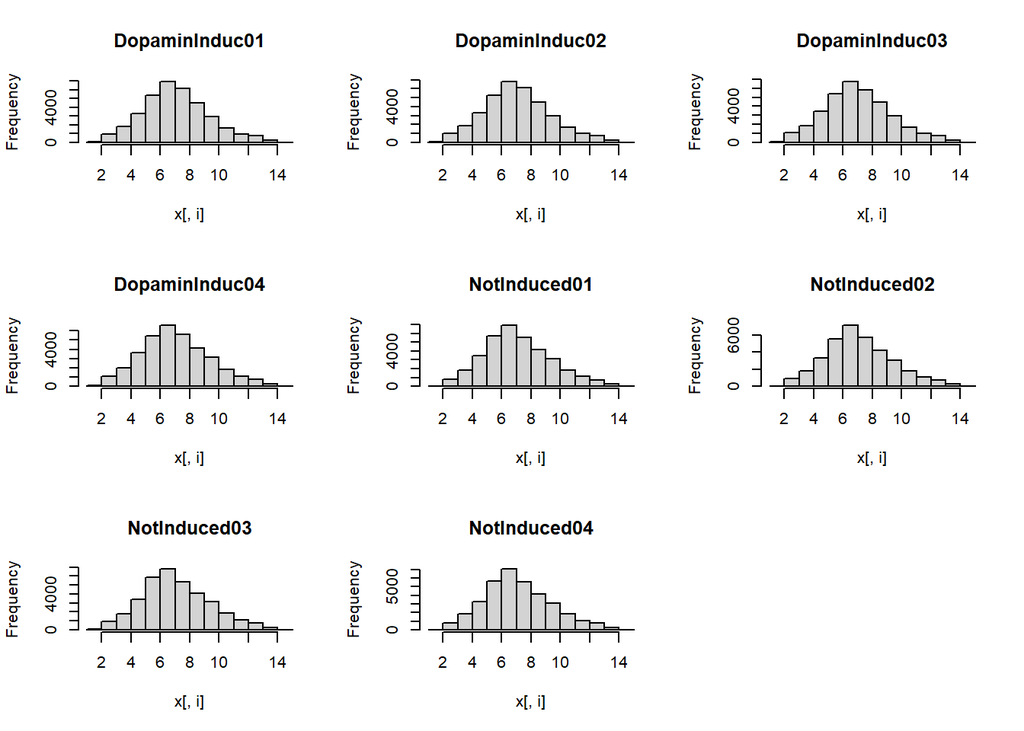

```r
opt <- par(mfrow=c(3,3))
for (i in 1:ncol(x))
  hist(x[,i], main = names(x)[i])
par(opt)
```

Or, a better option, boxplots which allow viewing all the samples at once and provide hints about the convenience of doing some type of preprocessing.

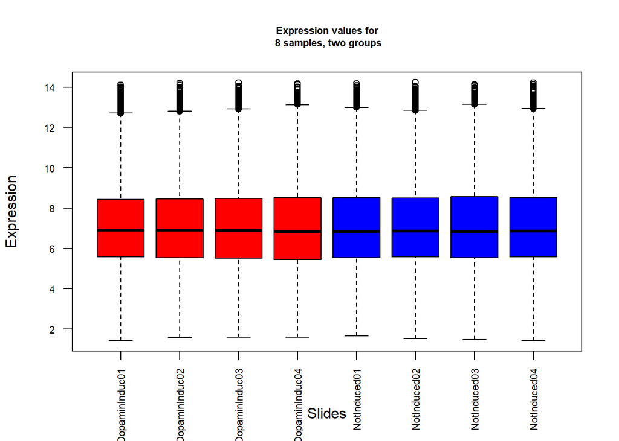

```r
groupColors <- c(rep("red", 4), rep("blue", 4))
boxplot(x, col=groupColors, main="Expression values for\n 8 samples, two groups",
    xlab="Slides",
    ylab="Expression", las=2, cex.axis=0.7, cex.main=0.7)
```

There is a slight assynmetry that might be corrected by taking logarithms

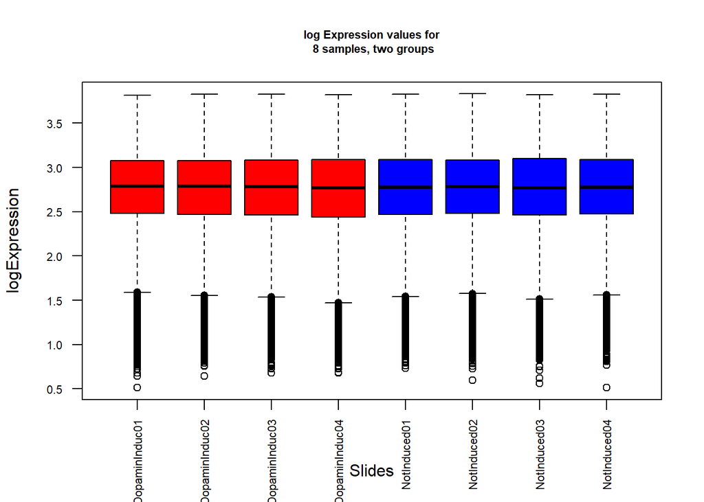

```r
logX <- log2(x)
groupColors <- c(rep("red", 4), rep("blue", 4))
boxplot(logX, col=groupColors, main="log Expression values for\n 8 samples, two groups",
    xlab="Slides",
    ylab="logExpression", las=2, cex.axis=0.7, cex.main=0.7)
```

Indeed the values downloaded from GEO have usually been preprocessed so what we obtain is a reasonable result.

## 3.2 Multivariate data visualization

A very useful plot is ibtained by computing “sample-wise” principal components and plotting the first two components. It can be used to detect unusual samples or batch effects.

First compute principal components and loadings.

```r
pcX<-prcomp(t(logX), scale=FALSE) # Ya se han escalado los datos
loads<- round(pcX$sdev^2/sum(pcX$sdev^2)*100,1)
```

Then plot the first two components.

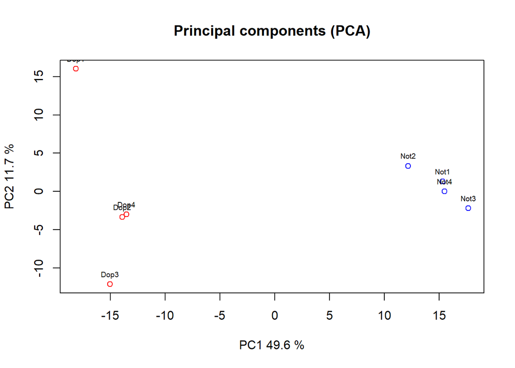

```r
xlab<-c(paste("PC1",loads[1],"%"))
ylab<-c(paste("PC2",loads[2],"%"))
plot(pcX$x[,1:2],xlab=xlab,ylab=ylab, col=groupColors,
     main ="Principal components (PCA)")
names2plot<-paste0(substr(names(x),1,3), 1:4)

text(pcX$x[,1],pcX$x[,2],names2plot, pos=3, cex=.6)
```

Alternatively a hierarchichal clustering can be used to visualize any expected (or discover an unexpected) grouping of the samples.

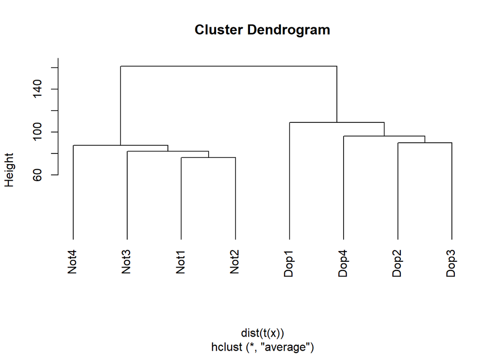

```r
colnames(x) <- names2plot
clust.euclid.average <- hclust(dist(t(x)),method="average")
plot(clust.euclid.average, hang=-1)
```

Both PCA and clustering show a clear grouping associated with treatment, which is rather common, except if there are unexpected issues such as problematic samples or batch effects.

## 3.3 Exercises

This exercises are intended for people who is starting to work with Bioconductor.

1. Go to the website of the Gene Expression Omnibus and Look for a comparative experiment that uses a small number of arrays and try to understand how the information is organized.
2. Download the expressions and the covariate information (both stored in the “Series Matrix File(s)”). Notice that **you need a ftp program such as filezilla to download the file**
3. Reproduce the exploration using the dataset you have downloaded. Feel free to complement it with any additional plot or summary which you fiond interesting.

# 4 Looking for differentially expressed genes

## 4.1 Comparing the expression between groups

In this section we assume that the data have already been normalized, so that we can proceed to compare them to see if there is differential expression between two conditions.

There exist packages implementing different variations of tests of differential expression as well as corrections for the multiple testing problem. However, following the idea of this document we rely on simple t-tests that we will iterate along the matrix.

First, we build

```r
ttest=function(x){tt=t.test(x[1:4],x[5:8])
return(c(tt$statistic,
         tt$p.value,
         tt$estimate[1]-tt$estimate[2]))
       }
```

and call it using `apply` again:

```r
ans <- apply(x,1,ttest)
ts <- ans[1,]
pvals<-ans[2,]
fc <-  ans[3,]
```

We can study the distribution of $t$ values obtained using a histogram or a “qq-plot”. In any case we must not forget that we are looking at the distribution of the test statistics not to that of the data. “qq-plot” of t-statistics can be used to suggest that there are diferentially expressed genes, that is genes whose values are higher or lower than expected by the null hypothesis of non-difference.

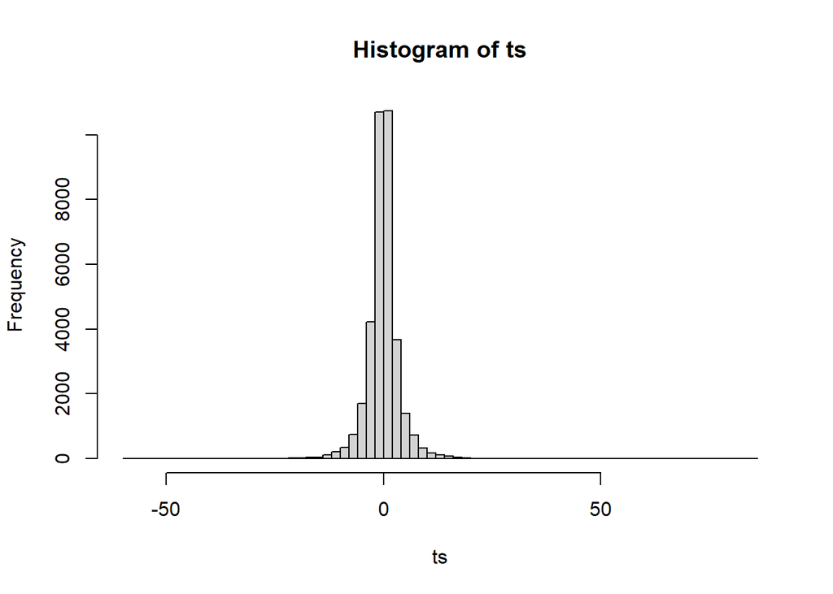

```r
hist(ts, breaks=100)
```

## 4.2 Calling genes *differentially expressed*

A gene is called “differentially expressed” if its expression is *significantly different* between two conditions. Following standard approaches of statistical testing (which, have been strongly criticized) We can call a gene differentially expressed if its p-value is under a given threshold.

Choosing the threshold is not trivial nor obvious, but to account for the problem of multiplicity of tests two common strategies are

- Adjusting the p-values
- Using a p-value much smaller than usual, combined with a minimum fold change to emphasize the need to combine “statistical significance” with “biological significance”.

```r
for (i in c(0.01, 0.001, 0.0001, 0.00001, 0.000001, 0.0000001))
  print(paste("genes with p-values smaller than", i, length(which(pvals < i))))
```

```
## [1] "genes with p-values smaller than 0.01 5652"
## [1] "genes with p-values smaller than 0.001 1965"
## [1] "genes with p-values smaller than 1e-04 647"
## [1] "genes with p-values smaller than 1e-05 177"
## [1] "genes with p-values smaller than 1e-06 36"
## [1] "genes with p-values smaller than 1e-07 6"
```

### 4.2.1 The volcano plot

A common way to visualize the results of a differential expression analysis is to use a *volcano plot* which plots the “fold change” vs “minus logarithm of the p-values”.

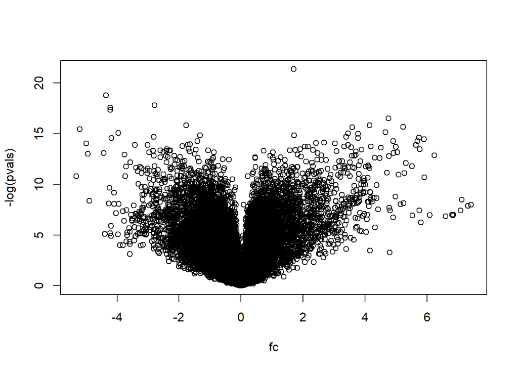

```r
plot(fc, -log(pvals))
```

In this plot, the genes which are “outer” and “upper” are the candidates for being differentially expressed.

# 5 References

- Clough, E., & Barrett, T. (2016). The Gene Expression Omnibus Database. In Methods in molecular biology (Clifton, N.J.) (Vol. 1418, pp. 93–110). https://doi.org/10.1007/978-1-4939-3578-9_5
- Cui, Dapeng, K. J. Dougherty, DW Machacek, S. Hochman, and D. J Baro. 2006. “Divergence Between Motoneurons: Gene Expression Profiling Provides a Molecular Characterization of Functionally Discrete Somatic and Autonomic Motoneurons.” Physiol Genomics 24 (3): 276–89. https://doi.org/ 10.1152/physiolgenomics.00109.2005.